# session 3 visualization tests

Let’s load the different examples files. Replace the file path `C:/Users/dmog/Documents/cours/stat_2022/Travaux_Pratiques/Session4_tets_partie2/data/` with yours.

```r
library(ggplot2)
library(tidyr)
library(dplyr)
library(ggbeeswarm)

df_bisphenol <- read.csv("data/ExerciceBisphenol.csv")

plasma <- readxl::read_xlsx("data/ExercicePlasmaCholesterol.xlsx")

pairedData <- readxl::read_xlsx("data/pairedData.xlsx")
```

# The functions to use:

## continuous variables

T test

```r
t.test
```

Wilcoxon (paired or not)

```r
wilcox.test
```

ANOVA (analysis of variance)

```r
aov
```

Kruskal Wallis

```r
kruskal.test
```

## binary variables

Fisher

```r
fisher.test
```

Mc Nemar

```r
mcnemar.test
```

Chi 2

```r
chisq.test
```

# Plasma

## Try to tranform to long:

```r
plasma
```

| Control | Treatment 1 | Treatment 2 |
| --- | --- | --- |
| 164.4 | 190.8 | 163.6 |
| 173.1 | 170.6 | 153.1 |
| 177.6 | 184.5 | 154.2 |
| 169.7 | 172.3 | 151.7 |
| 182.9 | 175.6 | 157.5 |
| 171.7 | 168.0 | 155.7 |
| 187.9 | 182.1 | 157.0 |
| 177.5 | 159.5 | 160.5 |
| 185.8 | 172.7 | 159.5 |
| 175.8 | 169.5 | 147.9 |

[output cut: 10 more lines]

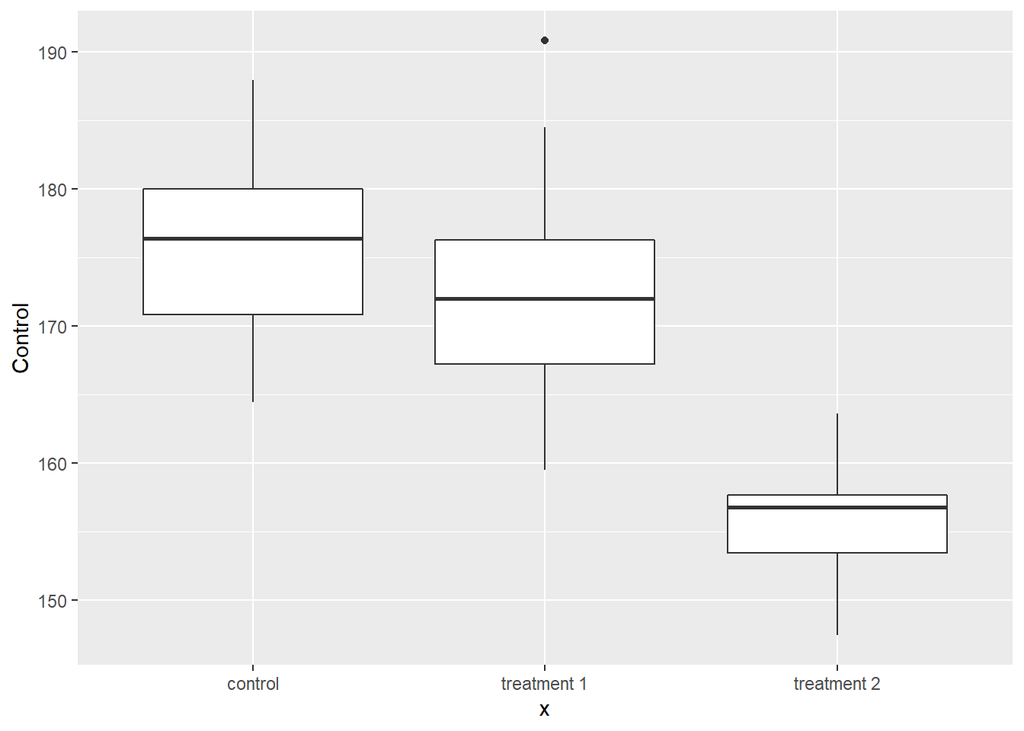

```r
ggplot(plasma)+
  geom_boxplot(aes(x = "control",y = Control))+
  geom_boxplot(aes(x = "treatment 1",`Treatment 1`))+
  geom_boxplot(aes(x = "treatment 2",`Treatment 2`))
```

```r
plasma_long <- pivot_longer(plasma,
                            cols = c("Control","Treatment 1","Treatment 2"),
                            values_to = "plasma",
                            names_to = "group")
plasma_long
```

| group | plasma |
| --- | --- |
| Control | 164.4 |
| Treatment 1 | 190.8 |
| Treatment 2 | 163.6 |
| Control | 173.1 |
| Treatment 1 | 170.6 |
| Treatment 2 | 153.1 |
| Control | 177.6 |
| Treatment 1 | 184.5 |
| Treatment 2 | 154.2 |
| Control | 169.7 |

[output cut: 50 more lines]

## make a plot (same as session 2)

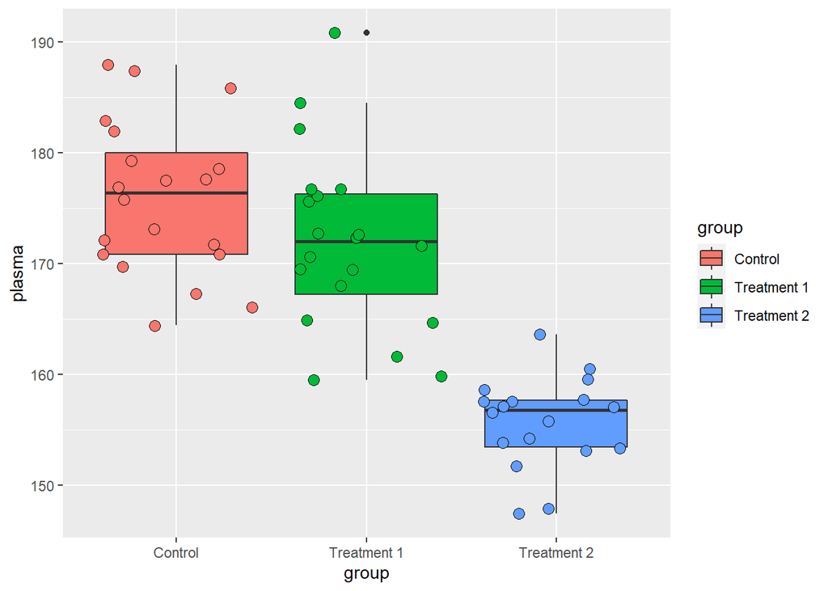

```r
ggplot(data=plasma_long,
       aes(x = group,
           y = plasma,
           fill=group))+  #define data and variables
  geom_boxplot()+
  geom_jitter(shape=21,show.legend = F,cex=3) #create one layer of graph
```

## test assumptions

- gaussian distrib in each group

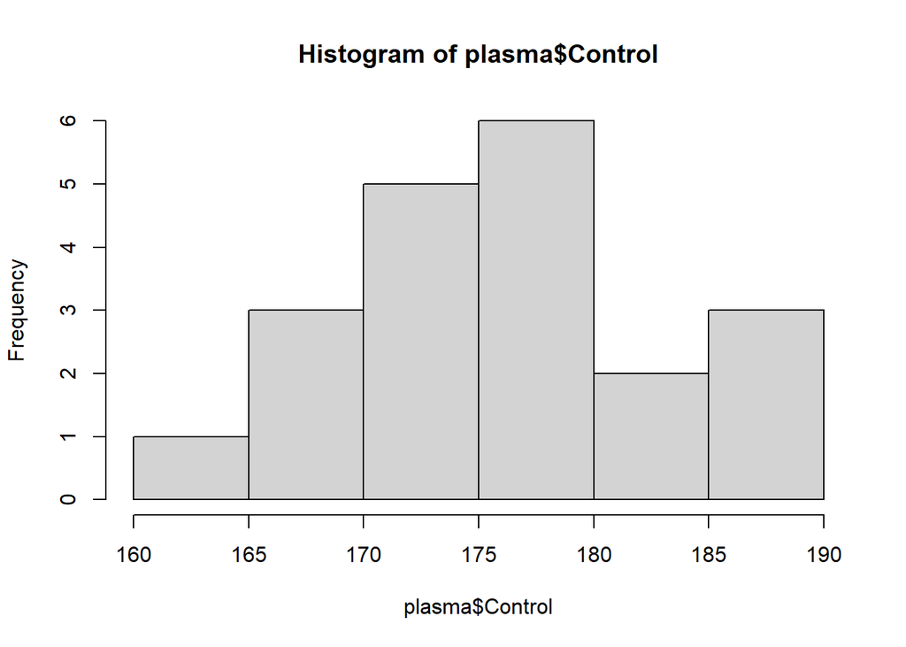

```r
hist(plasma$Control)
```

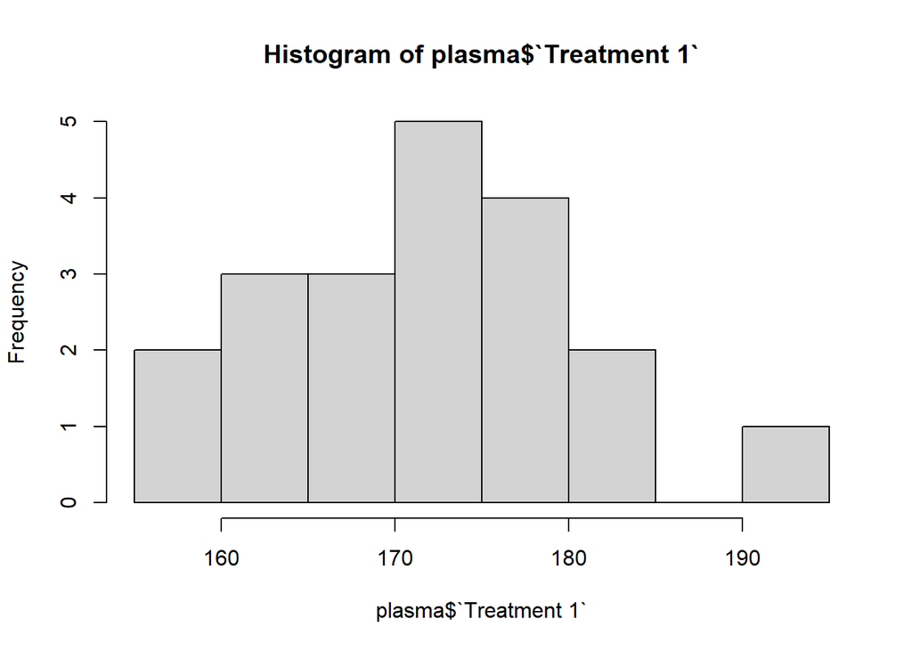

```r
hist(plasma$`Treatment 1`)
```

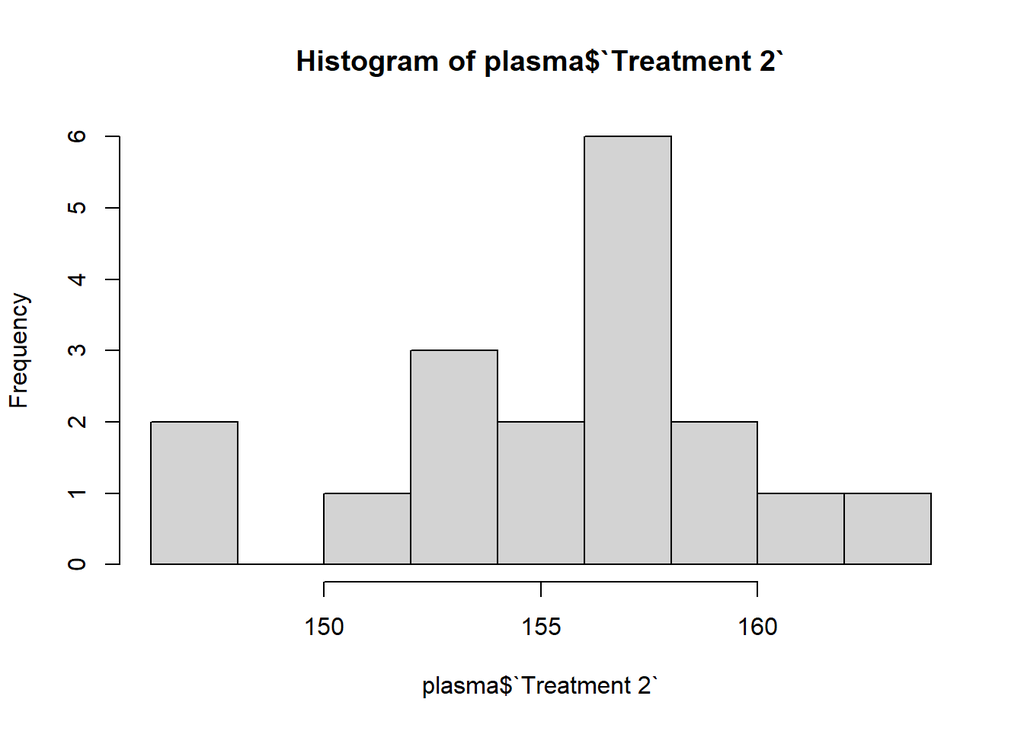

```r
hist(plasma$`Treatment 2`)
```

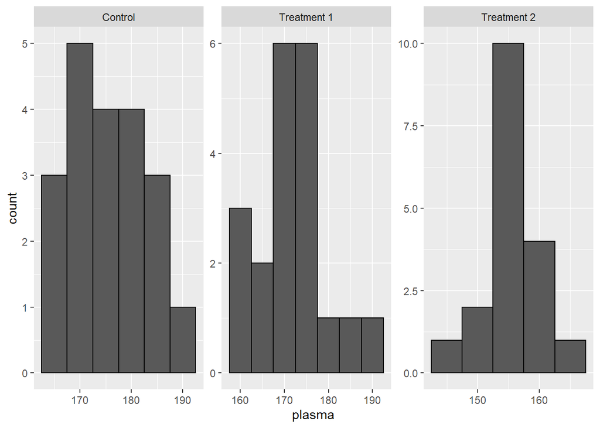

```r
plasma_long %>%
  ggplot()+
  geom_histogram(aes(plasma),
                 binwidth = 5,
                 color = "black")+
  facet_wrap(~group,scales = "free")
```

- variance similar

base:

```r
var(plasma$Control)
```

```
## [1] 48.34853
```

```r
var(plasma$`Treatment 1`)
```

```
## [1] 64.98239
```

```r
var(plasma$`Treatment 2`)
```

```
## [1] NA
```

Attention, la vairable treatment 2 contient des manquants!

```r
plasma$`Treatment 2`
```

```
##  [1] 163.6 153.1 154.2 151.7 157.5 155.7 157.0 160.5 159.5 147.9 153.3 157.5
## [13] 157.7 156.5 157.1 153.8 147.4 158.6    NA    NA
```

Il faut spécifiquement dire que il y a des manquants:

```r
var(plasma$`Treatment 2`,na.rm = T)
```

```
## [1] 16.89294
```

dplyr like:

```r
plasma_long %>%
  group_by(group)%>%
  dplyr::summarise(mean = mean(plasma,na.rm = T),
                   sd = sd(plasma,na.rm = T),
                   var = var(plasma,na.rm = T))
```

| group | mean | sd | var |
| --- | --- | --- | --- |
| Control | 175.870 | 6.953310 | 48.34853 |
| Treatment 1 | 171.985 | 8.061166 | 64.98239 |
| Treatment 2 | 155.700 | 4.110102 | 16.89294 |

Perform Anova and/or Kruskal-Wallis

```r
aov_res <- aov(plasma ~ group,
               data = plasma_long)

summary(aov_res)
```

```
##             Df Sum Sq Mean Sq F value   Pr(>F)
## group        2   4275  2137.7   48.18 8.13e-13 ***
## Residuals   55   2440    44.4
## ---
## Signif. codes:  0 '***' 0.001 '**' 0.01 '*' 0.05 '.' 0.1 ' ' 1
## 2 observations deleted due to missingness
```

- what does it means ? What is F ? What is p ?

F value is the value of the test statistics (ratio of inter group variance and intra group variance). The test statistics follow a F distribution

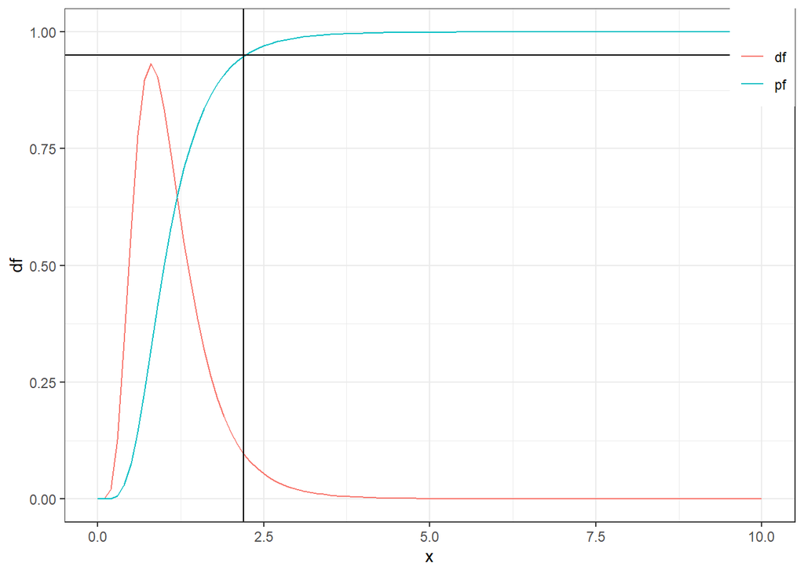

```r
N <- nrow(na.omit(plasma))
x <- seq(0,10,0.1)
data.frame(x = x,
           df = df(x,N,N),
           pf = pf(x,N,N)) %>%
  ggplot()+
  geom_line(aes(x,df,color = "df"))+
  geom_line(aes(x,pf,color = "pf"))+
  geom_hline(yintercept = .95)+
  geom_vline(xintercept = 2.2)+
  theme_bw()+theme(legend.position = c(1,1),
                   legend.justification = c(1,1))+
  labs(color = "")
```

Values of F above 2.2, i.e. when inter group variance is at least 2.2 intra group variance, implies that there is less than 5% of chance to obtain such test statistics or higher under the null Hypothesis.

```r
krus_res <- kruskal.test(plasma ~ group,data = plasma_long)
krus_res
```

```
##
##  Kruskal-Wallis rank sum test
##
## data:  plasma by group
## Kruskal-Wallis chi-squared = 37.021, df = 2, p-value = 9.143e-09
```

- make Tukey pairwise comparison

```r
TukeyHSD(aov_res)
```

```
##   Tukey multiple comparisons of means
##     95% family-wise confidence level
##
## Fit: aov(formula = plasma ~ group, data = plasma_long)
##
## $group
##                            diff        lwr        upr     p adj
## Treatment 1-Control      -3.885  -8.958961   1.188961 0.1648945
## Treatment 2-Control     -20.170 -25.382999 -14.957001 0.0000000
## Treatment 2-Treatment 1 -16.285 -21.497999 -11.072001 0.0000000
```

# paired data

- The level of a marker is measured at baseline and 1 week after injection of a product
- Sample: N=20 rabbits
- Aim: to assess and test the effect of the product between baseline and 1 week

```r
pairedData
```

| id | T0 | W1 |
| --- | --- | --- |
| 1 | 1.8864497 | 3.1000123 |
| 2 | 0.7670267 | 0.3325692 |
| 3 | 4.0719989 | 6.3628702 |
| 4 | 0.2162513 | 1.5131945 |
| 5 | 0.8219924 | -0.2111860 |
| 6 | 3.5911562 | 6.2550455 |
| 7 | 3.3404439 | 5.2266516 |
| 8 | 2.7265795 | 5.0082124 |
| 9 | 1.3628657 | 2.4558983 |
| 10 | 0.7499439 | 0.4942700 |

[output cut: 10 more lines]

## verify assumptions

- gaussian ?
- number of observations ?

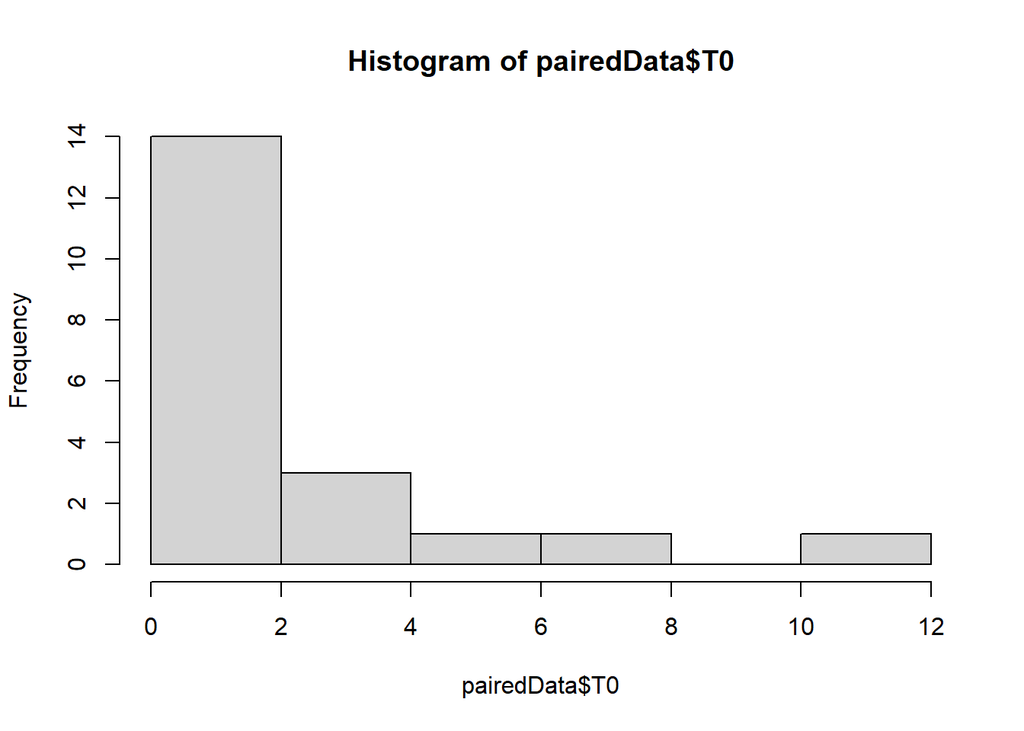

```r
hist(pairedData$T0)
```

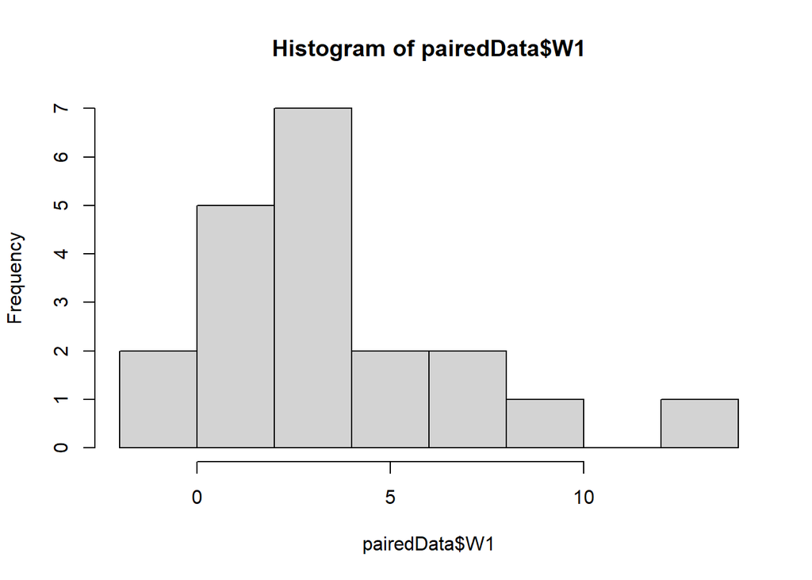

```r
hist(pairedData$W1)
```

Not Gaussian!

Other way: long format, then ggplot

```r
paired_long <- pairedData %>%
  pivot_longer(cols = c("T0","W1"),
               names_to = "time")
```

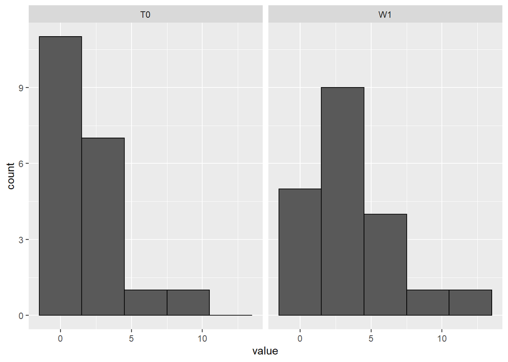

```r
paired_long %>%
  ggplot(aes(value))+
  geom_histogram(binwidth = 3,color = "black")+
  facet_wrap(~time)
```

## do the tests

- perform the proper test

The proper test is

```r
wilcox.test(pairedData$T0,pairedData$W1,paired=T)
```

```
##
##  Wilcoxon signed rank exact test
##
## data:  pairedData$T0 and pairedData$W1
## V = 16, p-value = 0.0003223
## alternative hypothesis: true location shift is not equal to 0
```

```r
wilcox.test(value ~ time, data = paired_long)
```

```
##
##  Wilcoxon rank sum exact test
##
## data:  value by time
## W = 148, p-value = 0.1653
## alternative hypothesis: true location shift is not equal to 0
```

- see the difference if using not paired

```r
wilcox.test(pairedData$T0,pairedData$W1,paired=F)
```

```
##
##  Wilcoxon rank sum exact test
##
## data:  pairedData$T0 and pairedData$W1
## W = 148, p-value = 0.1653
## alternative hypothesis: true location shift is not equal to 0
```

explanation:

If one looks without pairing, group do not look different:

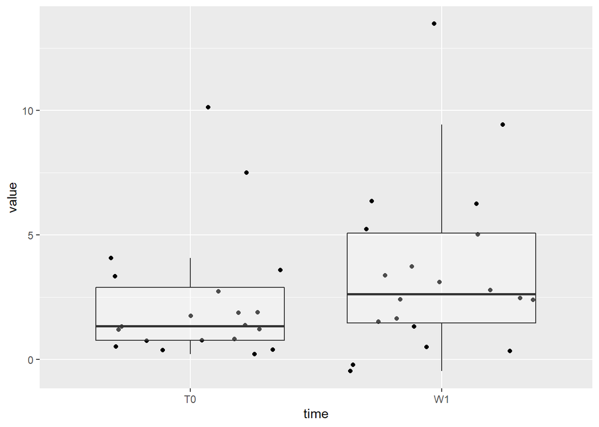

```r
pairedData %>%
  pivot_longer(cols = c("T0","W1"),
               names_to = "time")%>%
  ggplot(aes(time,value))+
  geom_jitter()+
  geom_boxplot(alpha = .3,outlier.shape = NA)
```

But if we connect lines, we see that most of the measures increase

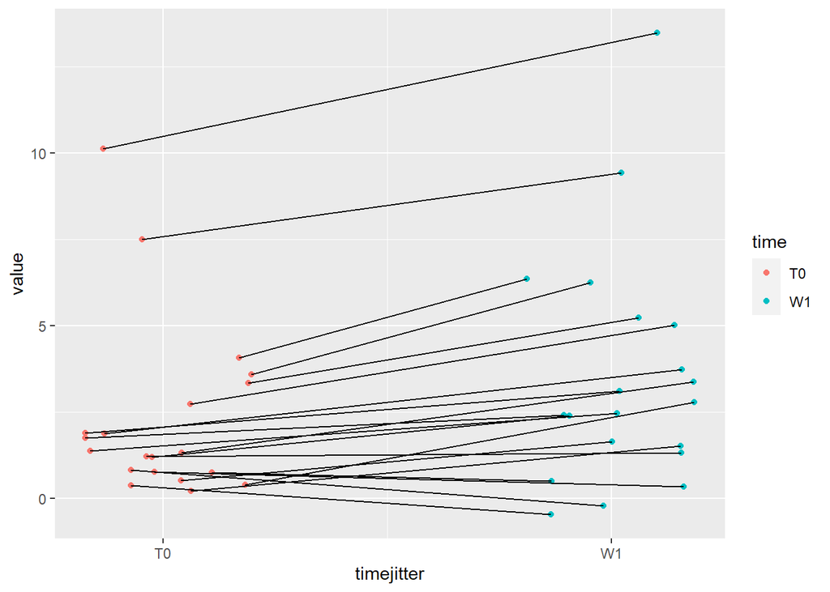

```r
paired_long$timejitter <- jitter(as.numeric(factor(paired_long$time)))

paired_long %>%
  ggplot(aes(timejitter,value))+
  geom_point(aes(color = time))+
  geom_line(aes(group = id))+
  scale_x_continuous(breaks = c(1,2),labels = c("T0","W1"))
```

An easy way to see it: look at the paired differences:

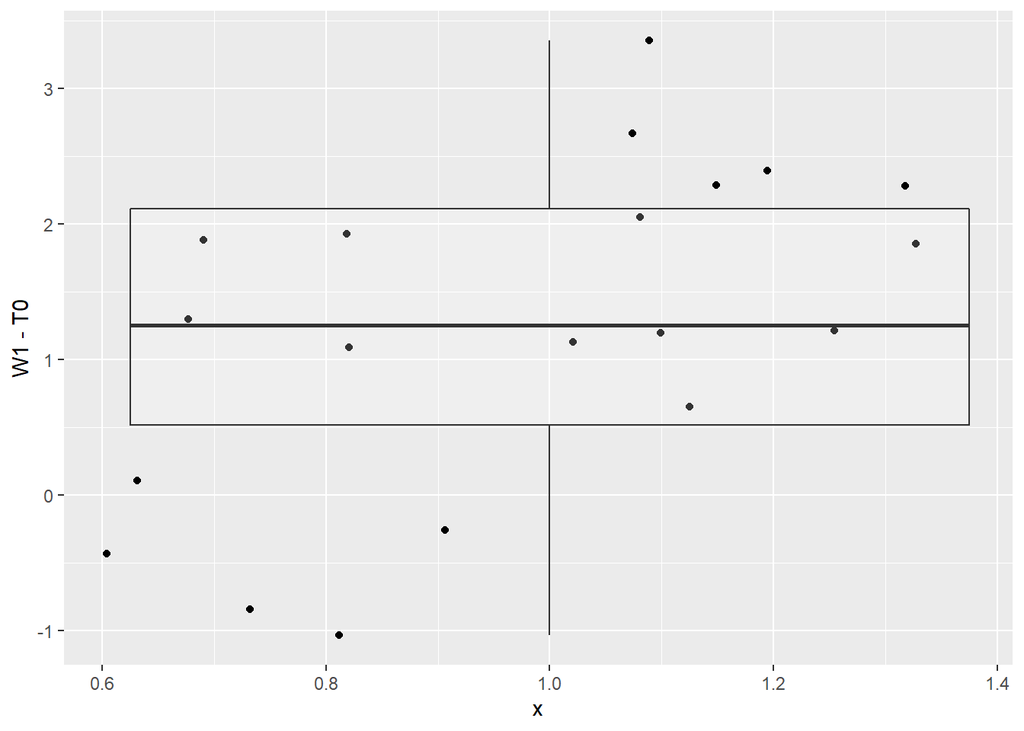

```r
pairedData %>%
  ggplot(aes(x = 1,y = W1-T0))+
  geom_jitter()+
  geom_boxplot(alpha = .2)
```

```r
t.test(pairedData$T0,pairedData$W1,paired=T)
```

```
##
##  Paired t-test
##
## data:  pairedData$T0 and pairedData$W1
## t = -4.5662, df = 19, p-value = 0.000211
## alternative hypothesis: true difference in means is not equal to 0
## 95 percent confidence interval:
##  -1.8111324 -0.6726327
## sample estimates:
## mean of the differences
##               -1.241883
```

## see test change

See if the ratio of level > 1 changes between baseline and 1 W

Let’s test if the rabbits who were above 1 at T0 are still above 1 at W1

```r
concordanceT0W1 <- table(pairedData$T0>1,pairedData$W1>1,dnn = c("T0","W1"))
concordanceT0W1
```

```
##        W1
## T0      FALSE TRUE
##   FALSE     4    3
##   TRUE      0   13
```

```r
mcnemar.test(concordanceT0W1)
```

```
##
##  McNemar's Chi-squared test with continuity correction
##
## data:  concordanceT0W1
## McNemar's chi-squared = 1.3333, df = 1, p-value = 0.2482
```